# Practical Machine Learning Course Assignment

Sum Nga Lai

Saturday, December 12, 2015

## Executive summary

Our goal is to use data from accelerometers on the belt, forearm, arm, and dumbell of 6 participants. They were asked to perform barbell lifts correctly and incorrectly in 5 different ways.

We are provided with a set of training data, another set as testing data, in regards of the participants movement data. We are required to find the most accurate model to predict the 20 records of class in testing data.

## Library used

```r
library(caret)
library(rpart)
```

```r
library(rpart.plot)
library(randomForest)
```

### Loading data

```r
training = read.csv("pml-training.csv", na.strings=c("NA","#DIV/0!", ""))
testing = read.csv("pml-testing.csv", na.strings=c("NA","#DIV/0!", ""))
```

### Cleaning training and testing data

We will remove some of the irrevelent variable: user_nam, raw_timestamp_part_1,raw_timestamp_part_2, cvtd_timestamp, new_window, num_window

Then, we will remove the variables that have 80% of their records as NA as they are not contributing to the model training process.

```r
#remove useless attribute: the first numbering row, user_nam, raw_timestamp_part_1,raw_timestamp_part_2,  cvtd_timestamp,   new_window, num_window
training   <-training[,-c(1:7)]
testing <-testing[,-c(1:7)]


##find out the variable that have more than 80% NA
m <- c()
for(i in 1:length(training))
  {
    totalNa <- sum(is.na(training[,i]))
    if((totalNa / nrow(training)) >.8)
       {
        m <- c(m, i)
       }
  }

##remove the variables with more than 80% NA
training <- training[, -m]
testing <- testing[,-m]

dim(training)
```

```
## [1] 19622    53
```

### Cross Validation

The training data will be subsampling into 60% of train set and 40% of test set. The model will be trained using the train set, later on to be predicted and tested on the test set. This is to check the accuracy of the trained model. The final chosen model will be later on used to predict the 20 records in the testing data.

```r
set.seed(5432)

subtrain <- createDataPartition(training$classe, p=0.60, list=FALSE)
trainset <- training[subtrain,]
testset <- training[-subtrain,]
```

## Model 1: Decision Tree

For the first model, we will use Decision Tree to train the model.

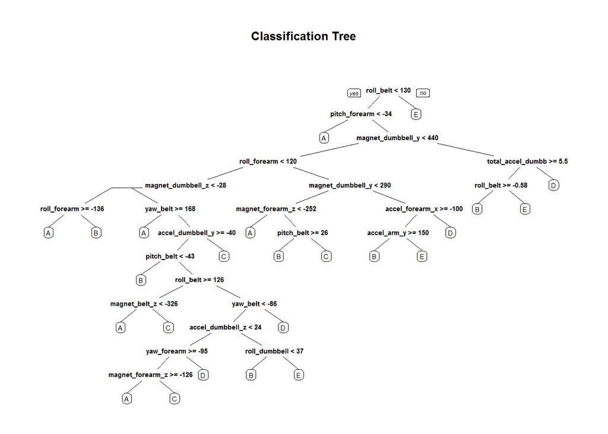

```r
modelrpart <- rpart(classe ~ ., data=trainset, method="class")
predrpart<- predict(modelrpart, testset, type = "class")

rpart.plot(modelrpart, main="Classification Tree")
```

```r
confusionMatrix(predrpart, testset$classe)
```

```
## Confusion Matrix and Statistics
##
##           Reference
## Prediction    A    B    C    D    E
##          A 1943  241   15   58   25
##          B   89  933  134  105  166
##          C   73  160 1098  213  167
##          D   86  115   84  806   78
##          E   41   69   37  104 1006
##
## Overall Statistics
##
##                Accuracy : 0.7374
##                  95% CI : (0.7276, 0.7472)
##     No Information Rate : 0.2845
##     P-Value [Acc > NIR] : < 2.2e-16
##
##                   Kappa : 0.6677
##  Mcnemar's Test P-Value : < 2.2e-16
##
## Statistics by Class:
##
##                      Class: A Class: B Class: C Class: D Class: E
## Sensitivity            0.8705   0.6146   0.8026   0.6267   0.6976
## Specificity            0.9396   0.9219   0.9054   0.9447   0.9608
## Pos Pred Value         0.8514   0.6538   0.6417   0.6895   0.8003
## Neg Pred Value         0.9481   0.9089   0.9560   0.9281   0.9338
## Prevalence             0.2845   0.1935   0.1744   0.1639   0.1838
## Detection Rate         0.2476   0.1189   0.1399   0.1027   0.1282
## Detection Prevalence   0.2908   0.1819   0.2181   0.1490   0.1602
## Balanced Accuracy      0.9051   0.7683   0.8540   0.7857   0.8292
```

The Accuracy of the model using Decision Tree is 0.7374

## Model 2: Random Forest

For the second model, we will use Random Forest instead.

```r
modelrf <- randomForest(classe ~. , data=trainset)

predrf <- predict(modelrf, testset, type = "class")

confusionMatrix(predrf, testset$classe)
```

```
## Confusion Matrix and Statistics
##
##           Reference
## Prediction    A    B    C    D    E
##          A 2228   10    0    0    0
##          B    3 1502   15    0    0
##          C    0    6 1352   20    0
##          D    0    0    1 1265    2
##          E    1    0    0    1 1440
##
## Overall Statistics
##
##                Accuracy : 0.9925
##                  95% CI : (0.9903, 0.9943)
##     No Information Rate : 0.2845
##     P-Value [Acc > NIR] : < 2.2e-16
##
##                   Kappa : 0.9905
##  Mcnemar's Test P-Value : NA
##
## Statistics by Class:
##
##                      Class: A Class: B Class: C Class: D Class: E
## Sensitivity            0.9982   0.9895   0.9883   0.9837   0.9986
## Specificity            0.9982   0.9972   0.9960   0.9995   0.9997
## Pos Pred Value         0.9955   0.9882   0.9811   0.9976   0.9986
## Neg Pred Value         0.9993   0.9975   0.9975   0.9968   0.9997
## Prevalence             0.2845   0.1935   0.1744   0.1639   0.1838
## Detection Rate         0.2840   0.1914   0.1723   0.1612   0.1835
## Detection Prevalence   0.2852   0.1937   0.1756   0.1616   0.1838
## Balanced Accuracy      0.9982   0.9933   0.9921   0.9916   0.9992
```

The Accuracy of the model trained using Random Forest is 0.9925

Therefore, the model trained using Random Forest is chosen to predict the Testing date.

## Expected out-of-sample error

As we have a relatively large sample size which we have 19622 records in the training data, we can perform cross-validation checking on the data by subsampling 60% of the data as train set and 40% as test set. Variables that are irrelevant were removed to avoid affecting the model training process.

The expected out-of-sample error is calculated as 1 - accuracy. As the accuracy of the model trained using Random Forest on our cross-validation data, which is 0.9925, the expected out-of-sample error will be 0.0075, which is relatively low. We can expect that the accuracy of the predicted outcome will be consistently high.

## Generate predicted result of the testing data

Using the chosen model, we will generate the predicted outcome of the testing data into txt files.

```r
predBestFit <- predict(modelrf, testing, type = "class")

pml_write_files = function(x){
  n = length(x)
  for(i in 1:n){
    filename = paste0("problem_id_",i,".txt")
    write.table(x[i],file=filename,quote=FALSE,row.names=FALSE,col.names=FALSE)
  }
}

pml_write_files(predBestFit)
```